# [TWD] Praca Domowa nr 5

Szymon Maksymiuk

20 listopada 2018

# Wstęp

Postanowiłem pochwylić się nad danymi dotyczącymi spożycia alkoholu w Wielkiej Brytanii. Przedstawiają one grupy wiekowe oraz to jaki procent osób z danej grupy spożywa alkohol. Według mnie są to idealne dane do tego eksperymantu, gdyż można ja przedstawiać na wiele sposobów, również takich mogących wprowadzić w błąd. Niżej zaprezentuję dwa wykresy, jeden zrobiony tak aby utrudnić życie użytkownikowi, starać się wprowadzić go w błąd, drugi natomiast próbujący jak najabrdziej rzetelnie przedstawić dane. Następnie prosiłem ankietowanych aby odpowiedzieli na 3 takie same pytania, najpierw patrząc na gorszy wykres, a potem na lepszy. Wyniki są zdumiewające.

## Wykres 1

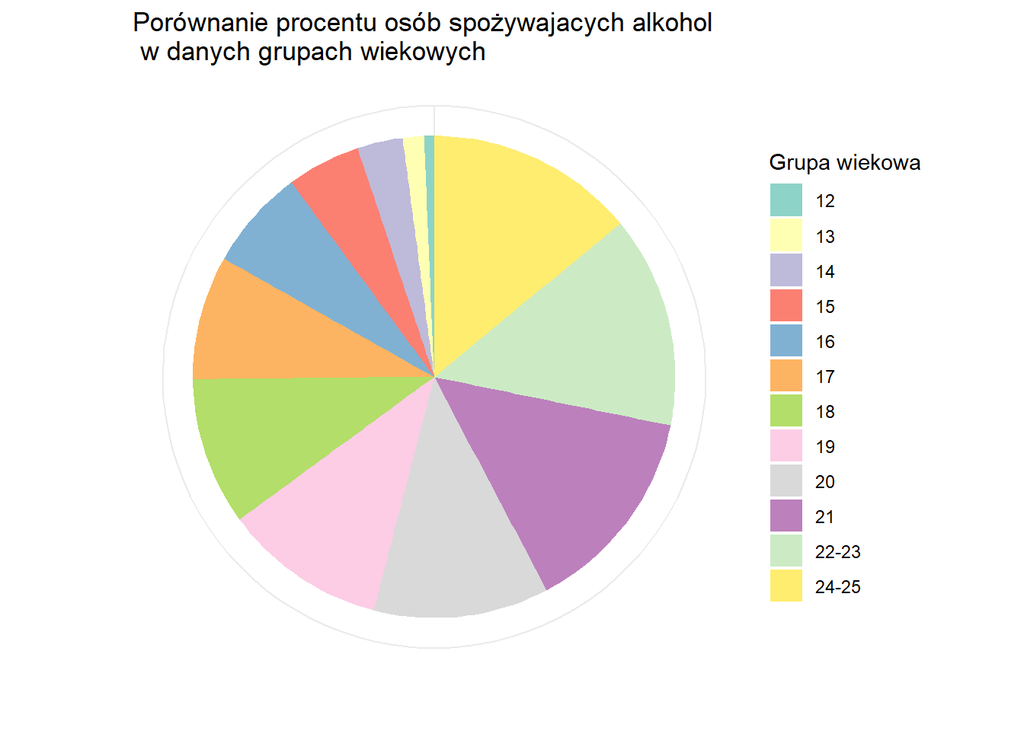

Wykres jest klasycznym beznadziejnym i błędnym zastosowaniem wykresu kołowego. Przede wszystkim sugeruje, że nasze dane sumują się do pewnej całości, podczas gdy przecież wcale tak nie jest. Tracimy również dokładne dane liczbowe (specjalnie w obu wersjach wykresu pominę podpisy z wartościami). Jedyną rzeczą, do której mógłby być przydatny jest porównanie poszczególnych wycinków w celu stiwerdzenia, która z grupa ma większy odsetek spożywania alkoholu, co z kolei mija się z celem z innego powodu. Wielkości wycinków kołowych bardzo trudno się porównuje.

## Wykres 2

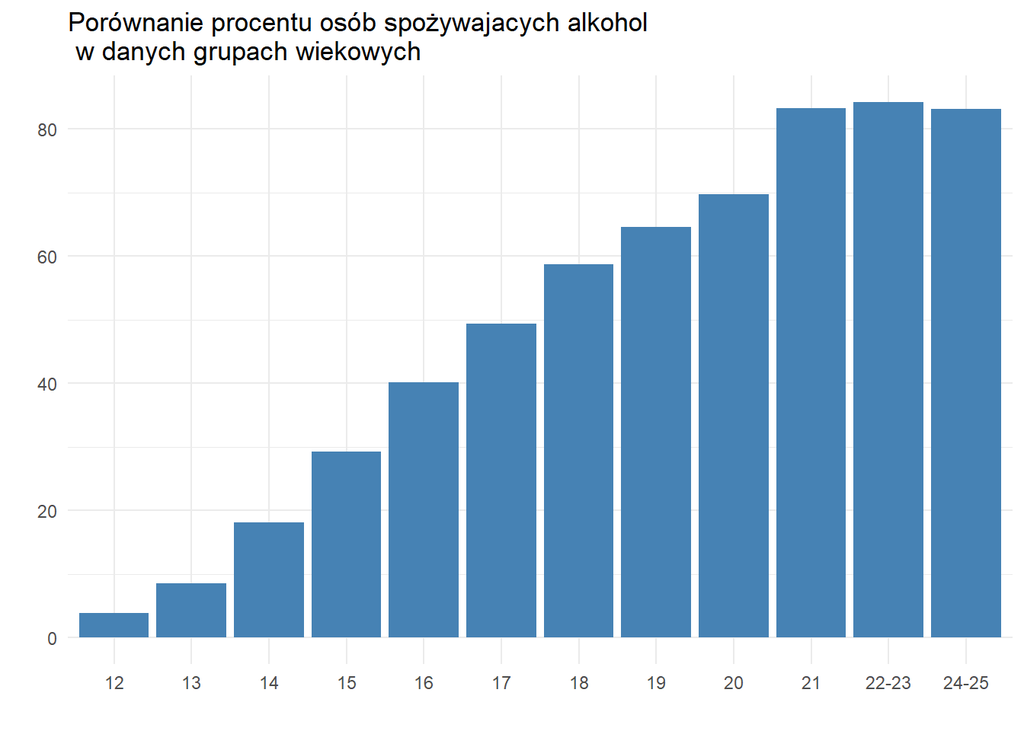

Drugi wykres został przygotowany rzetelnie. Zastosowane słupki idealnie nadają się do prównywania wartości, które razem nie stanowią pewnej całości. W takiej formie również nie jest najmniejszym problemem stwierdzenie, która kategoria jest najabrdziej liczna.

# Ankieta

## Część pierwsza

Pytania w tej części odnoszą się do pierwszego, gorszego wykresu

### Pytanie 1

Czy można stwierdzić jaką część wszystkich osób spożywających alkohol stanowią osiemnastolatkowie?

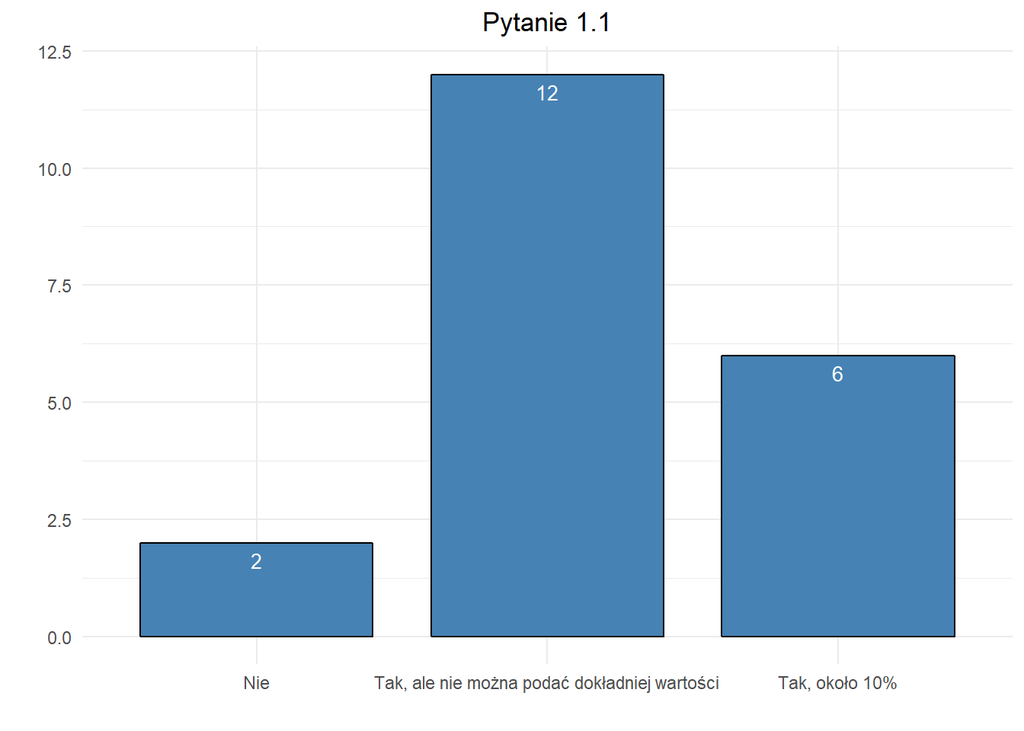

Jak widać udało się nam zmanipulować odbiorcę. Oczywiście nie jesteśmy w stanie tego stwierdzić, ponieważ jak już wyżej wspomniałem, mamy do czynienia z danymi procentowami, takimi, które nie sumują się do całości. Dodatkowo jak widać po legendzie nie mmamy nawet uwzględnionych wszystkich grup wiekowych. Niestety (stety) zastosowanie wykresu kołowego skłoniło odbiorców do błędnej oceny.

### Pytanie 2

Czy na wykresie są grupy wiekowe o takim samym odsetku osób spożywających alkohol? Jeżeli tak to ile jest takich wartości, które są wspólne dla kilku grup?

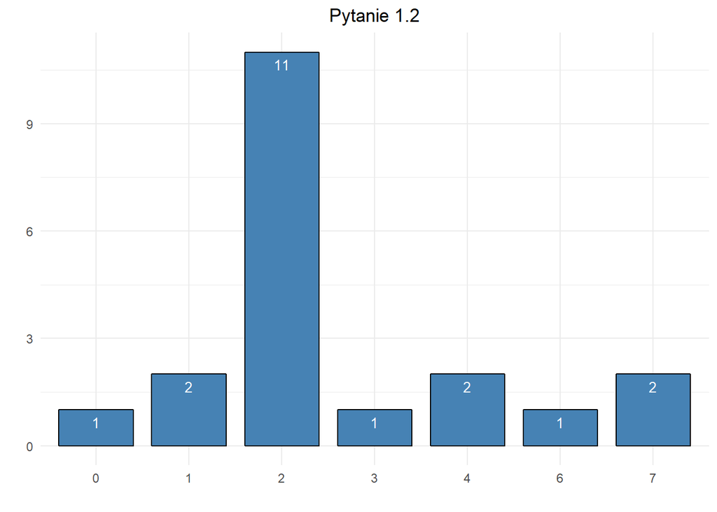

Ponownie, dzięki temu, że na wykresie kołowym trudno porównuje się dane, udało nam się wprowadzić odbiorcę w błąd. Tak naprawdę, jak widzieliśmy na wykresie słupkowym, tych wartości, zależnie od dokładności, jest 0 lub 1 (wynika to z tego, że różnica pomiędzy pewnymi trzema grupami jest minimalna)

### Pytanie 3

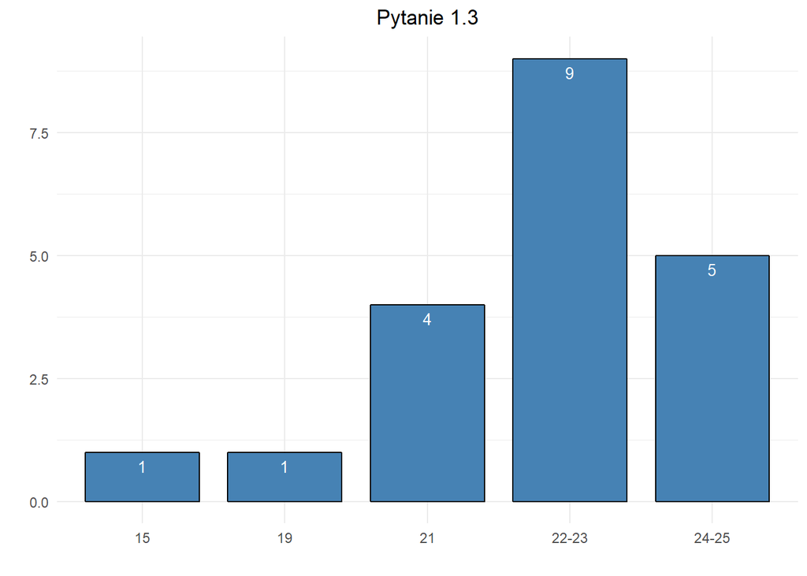

W odróżnieniu do poprzednich pytań, w tym wypadku dobra odpowiedź ma najwięcej odpowiedzi. Jednakże fakt, że nie wszyscy odpowiedzieli poprawnie na tak kluczowe i w gruncie rzeczy proste pytanie ponownie pokazuje, że błędne kodowanie danych (w typ wypadku uzycie wykresu kołowego) sprzyja manipulacji.

## Część druga

W tej część pytania odnosić się będą do drugiego, lepszego wykresu.

### Pytanie 1

Czy można stwierdzić jaką część wszystkich osób spożywających alkohol stanowią osiemnastolatkowie?

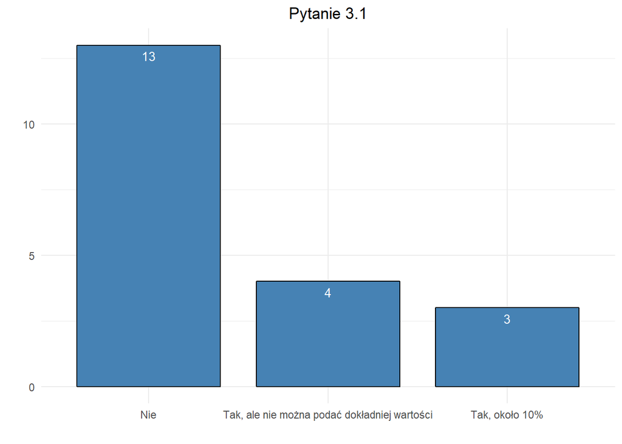

W tym wypadku, ankietowani już częściej wybierali poprawną odpowiedź. Pozbawieni błędnej sugestii w postaci wykresu kołowego mieli łatwiej stwierdzić co tak naprawdę wykres przedstawia.

### Pytanie 2

Czy na wykresie są grupy wiekowe o takim samym odsetku osób spożywających alkohol? Jeżeli tak to ile jest takich wartości, które są wspólne dla kilku grup?

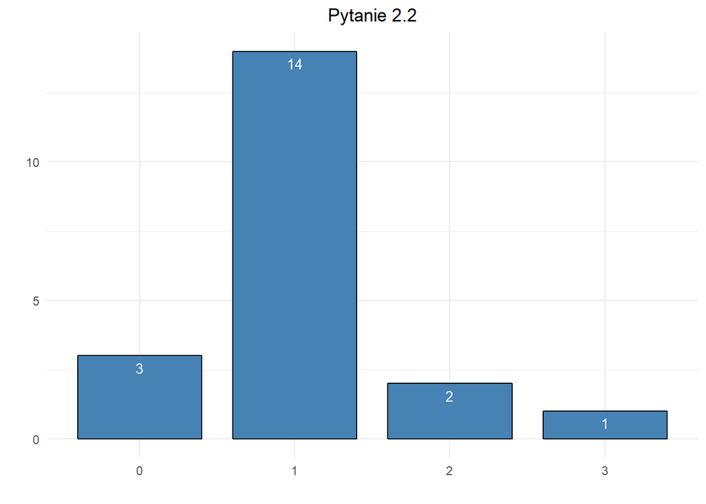

Tym razem, mając poprawnie wykonany wykres przed oczami, ankietowani niemal bezłędnie wskazali poprawne wartości.

### Pytanie 3

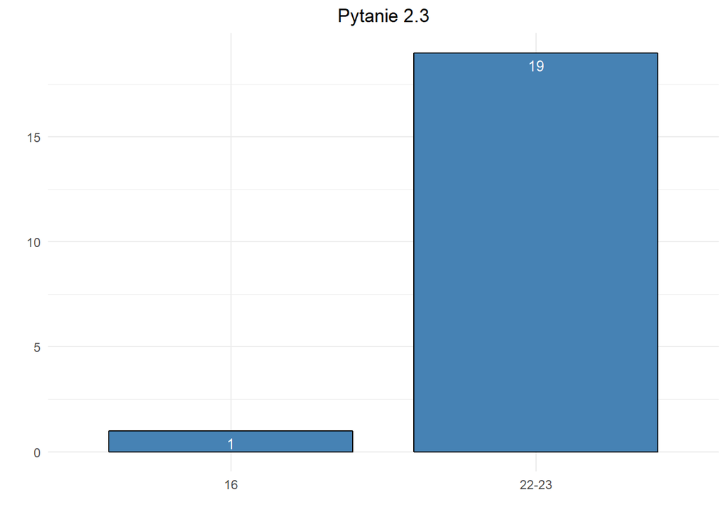

Niemal wszyscy ankietowani odpowiedzieli poprawnie na to pytanie. Myślę, że z czystym sumieniem możemy uznać odpowiedź “16” za outlier.

# Podsumowanie

Na koniec ankiety zadałem trzy pytania na temat tego jak się ankietowanym pracowało z poszczególnymi wykresami.

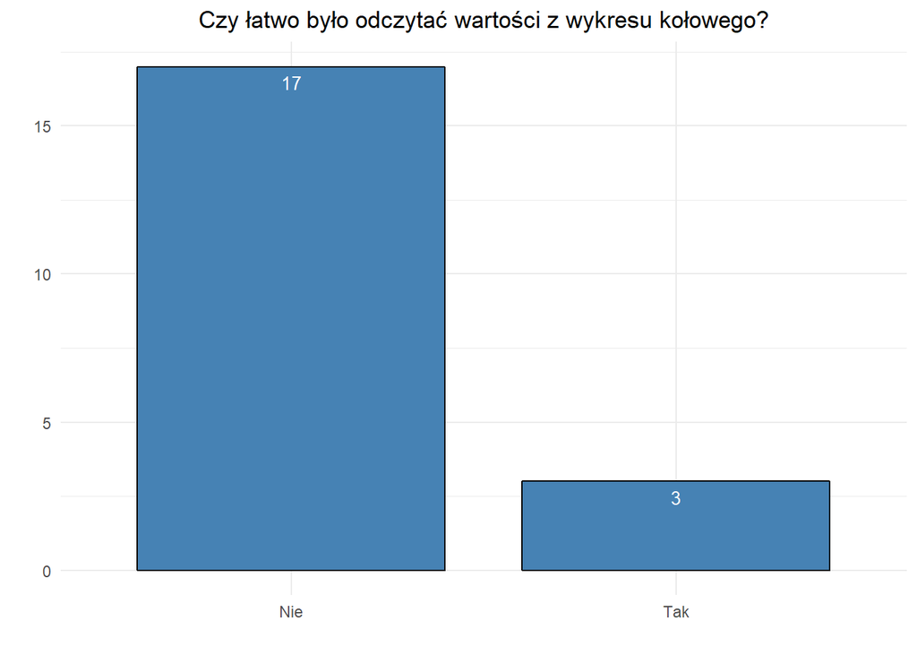

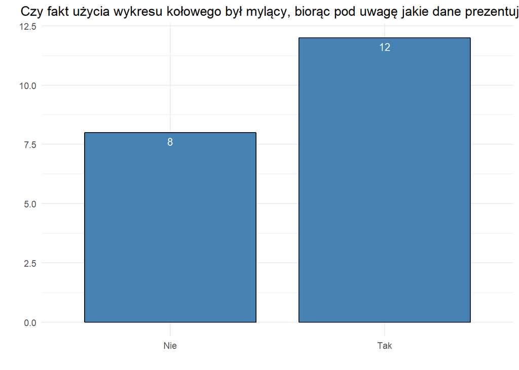

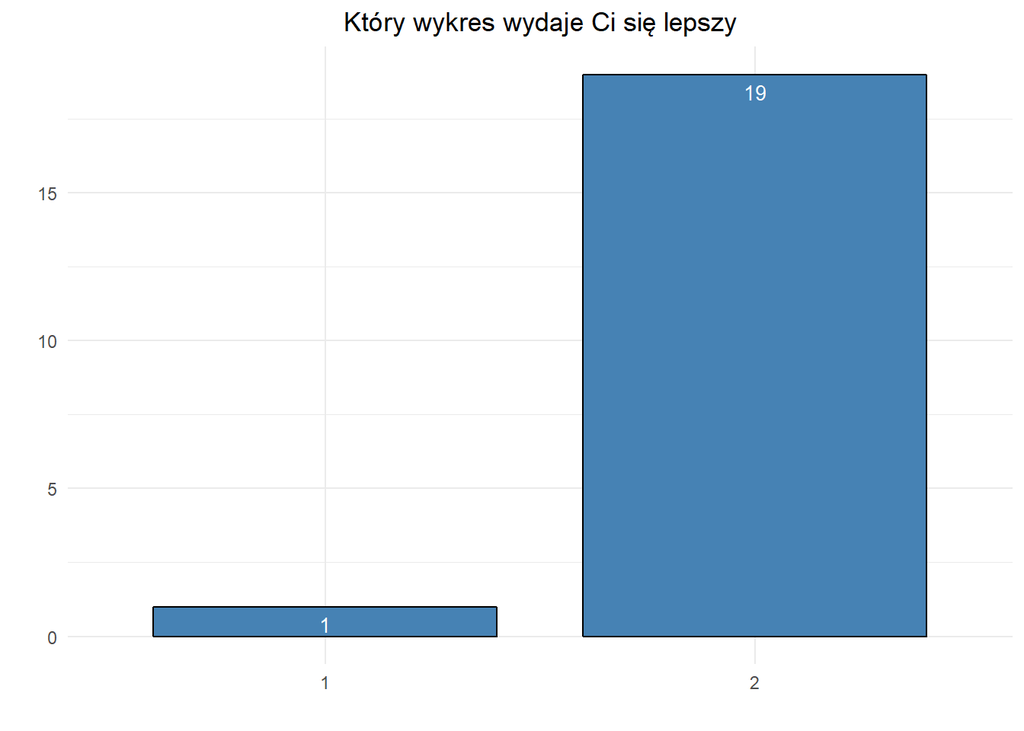

Z przedstawionych odpowiedzi jasno wynika, że ankietowanym lepiej się pracowało z wykresem słupkowym. Biorąc teraz pod uwagę wszystkie odpowiedzi, możemy stwierdzić, że w istocie, nieumiejętne dobierania rodzajów wykresów do danych może prowadzić nie błędnych odczytów oraz zakłamań. Niestety czytelnicy wciąż często polegają na pierwszym wrażeniu co pokazuje jak bardzo musimy się mieć na baczności prezentując dane.